# Lecture 4.1

Likert Scales and Cronbach’s Alpha Reliability

### Measuring Continuous Variation Using Scales

Last lecture, we learned about the strengths and limitations in using **self-reports surveys** to measure variation. In this lecture, we’ll first **define** likert scales and explain how and why they are used by psychologists to measure continuous variation. Next, I’ll **demonstrate** how to use R to create a likert scale from the class dataset. Finally, you’ll get a chance to **use R** apply these skills and create a different likert scale from the class dataset using R.

- Back to Home

**Click on the tabs below to navigate to each part of the Lecture Notes. Make sure to read all parts of this document.**

#### Definition

A **likert scale** is a common measure psychologists use to capture continuous variation. Likert scales can be used for self-report surveys, or given to observers to make judgments or ratings of some target person.

##### Features of a likert scale.

- **“scale”**" : this is the the variable that you want to measure.
- **item(s)** : these are the specific question(s) in the scale. There are two types of items:
  - *positive keyed items* : measure the high end of the scale.
  - *negative keyed items* : measure the low end of the scale.
- **response scale** : this is how people answer the questions of the scale.
  - in general, it’s best to provide an *odd number* of response options to allow people to give a ‘neutral’ response that’s in the middle of the scale (since the normal distribution assumes that most people *should* fall into the middle of a distribution).
  - I also like to limit the range of the response scale to avoid somethign called a *response style effects*, which measures individual differences in how people answers scales, and is not really related to the variation you want to measure. For example, the difference between a 1 and a 2 on a 5-point scale of how much you like R is probably more meaningful than the difference between a 20 and 25 on a 100-point scale.
  - Finally, it’s considered good practice to provide labels to the values of the response scale (e.g., 1 = Strongly Disagree; 2 = Disagree; 3 = Neutral; 4 = Agree; 5 = Strongly Agree.) This gives people some meaning for what a 1 or a 5 means, and helps reduce confusion (and thus, error).

> [WATCH THIS](https://www.youtube.com/watch?v=W32cHuaWwMU) : a video with an example of these terms in the context of an Extraversion scale.

> **[Check-in here to assess your understanding of likert scales](https://docs.google.com/forms/d/e/1FAIpQLSfZqNV9KkpU9nvUv90-nPVmdcY0iSvmbfy7yQpYx9Fnt3GunA/viewform?usp=sf_link).**

##### Now, click on the “In R” tab at the top of this document to learn how to create a scale in R.

#### In R

In this demonstration, we’ll use the class dataset to create a scale to measure differences in EXTRAVERSION. To do this, we will need to complete the following steps:

1. Import and check the data.
2. Isolate the positively and negatively-keyed items.
3. Reverse-score the negatively-keyed items.
4. Create a new variable that is the average of each person’s items.
5. Graph this variable
6. Evaluate the reliability of this variable.

Whew! Let’s get started.

First, we’ll need to load the data, and check to make sure it imported correctly.

```r
class <- read.csv("~/Dropbox/STATS/Data/!StudentData/class_dataset_SP20.csv") # Note: make sure to change the *path* in the `read.csv()` function to point R to the correct spot to import the class dataset from YOUR computer.
head(class)[1:4, 1:15] # the indexing just looks at the first 4 rows and first 15 variables.
```

```
##   e1 e2 e3 e4r e5r e6r c1 c2r c3 c4r c5r c6 c7 c8 o1
## 1  2  3  4   4   4   4  5   1  5   1   1  5  5  2  3
## 2  3  2  2   4   4   4  4   2  4   3   4  5  5  4  3
## 3  5  4  3   4   4   4  2   3  4   3   5  2  4  4  4
## 4  1  2  2   4   4   4  4   2  4   1   1  5  5  2  2
```

```r
nrow(class) # looks good!
```

```
## [1] 150
```

Now, I’ll just create a smaller dataframe of the variables that I want to work with for the extraversion scale. From the codebook, I see that the extraversion scale is made up of the items e1-e6r, with the r indicating items that are negatively-keyed.

```r
extraPOS.df <- data.frame(class$e1, class$e2, class$e3) #the `cbind()` function to combine three objects (my positively keyed items) into a new dataframe, where each item is its own column.

extraNEG.df <- with(class, data.frame(e4r, e5r, e6r)) # For the negatively-keyed items, I'm doing the same thing. However, I'm also using the `with()` function to apply the "class" dataset to these variables - this cuts down on the amount of typing I have to do, and makes it easier to change the name of the dataset if I want to use this code for some other problem.

head(extraPOS.df) # this code checks my work and make sure these newly created dataframes in fact contain the positively and negatively keyed items.
```

```
##   class.e1 class.e2 class.e3
## 1        2        3        4
## 2        3        2        2
## 3        5        4        3
## 4        1        2        2
## 5        3        3        3
## 6        3        4        5
```

```r
head(extraNEG.df)
```

```
##   e4r e5r e6r
## 1   4   4   4
## 2   4   4   4
## 3   4   4   4
## 4   4   4   4
## 5   4   4   5
## 6  NA   2   3
```

Now, I need to reverse-score the negatively keyed items. Since the scale ranged from 1 to 5, I can subtract the negatively keyed items from 6 to reverse the scoring (so 6 - 1 = 5, and 6 - 5 = 1.)

I can again use the `head()` function to check my work and confirm that I successfuly reverse scored the variables.

```r
extraNEGR.df <- 6-extraNEG.df
head(extraNEGR.df)
```

```
##   e4r e5r e6r
## 1   2   2   2
## 2   2   2   2
## 3   2   2   2
## 4   2   2   2
## 5   2   2   1
## 6  NA   4   3
```

Now, I need to create one scale that is the combination of the positively keyed and negatively keyed items.

```r
EXTRA.df <- cbind(extraPOS.df, extraNEGR.df) # this combines the positively and (reverse-scored) negatively keyed items.

rowMeans(EXTRA.df) # this calculates the average of these items for each row (individual) in the dataset. This is the measure of extraversion for each person. Notice that there is some missing data - the default for this code is that a person's data will be totally removed if they didn't answer all the questions in the scale. This is a very conservative way to handle missing data.
```

```
##   [1] 2.500000 2.166667 3.000000 1.833333 2.333333       NA 2.333333
##   [8] 3.833333 3.500000 3.666667 3.000000 2.833333 2.333333 3.000000
##  [15] 3.000000 4.166667 3.666667 4.000000 2.666667 2.333333 3.000000
##  [22] 4.000000 4.833333 1.666667 2.000000 3.333333 3.166667 2.166667
##  [29] 3.500000 4.166667 1.666667 2.666667 3.000000 3.166667 3.833333
##  [36] 4.500000 2.833333 3.666667 3.166667 2.666667 5.000000 2.500000
##  [43] 1.000000 3.666667 3.833333 3.166667 3.000000 2.500000 3.500000
##  [50] 2.166667 1.833333 3.000000 3.166667 2.666667 2.666667 3.833333
##  [57] 3.000000 3.000000 3.333333 2.500000 4.666667 2.333333 2.500000
##  [64] 1.833333 2.166667 2.666667 1.833333 2.500000 3.000000 3.000000
##  [71] 4.833333 4.833333 3.666667 2.500000 2.333333 2.166667 3.000000
##  [78] 1.666667 3.500000 3.500000 3.000000 2.666667 2.833333 3.833333
##  [85] 3.666667 2.833333 3.166667       NA 2.333333 1.833333 2.000000
##  [92] 3.500000 2.333333 2.333333 3.000000 3.333333 3.333333 2.833333
##  [99] 3.166667 3.166667 3.500000 3.666667 4.000000 2.333333 2.500000
## [106] 3.166667 4.000000 3.500000 3.333333 3.500000 3.666667 2.833333
## [113] 3.500000 2.333333 3.333333 1.000000 3.166667 3.166667 2.833333
## [120] 3.666667 4.000000 3.333333 3.166667 5.000000 2.500000 3.166667
## [127]       NA 2.333333 2.333333 2.000000 2.333333 3.000000 3.000000
## [134] 3.500000 2.333333 2.166667 3.000000 3.500000 3.166667 3.500000
## [141] 2.333333 3.333333 3.000000 2.333333       NA 3.500000 3.000000
## [148] 3.000000 4.333333 3.666667
```

```r
rowMeans(EXTRA.df, na.rm = T) # this removes missing data from specific items, so the average score will be calculated even if the person didn't answer some of the items. This is less conservative. It's up to you how conservative you want to be when it comes to missing data - just explain what you did in your code (and lab / research paper).
```

```
##   [1] 2.500000 2.166667 3.000000 1.833333 2.333333 3.800000 2.333333
##   [8] 3.833333 3.500000 3.666667 3.000000 2.833333 2.333333 3.000000
##  [15] 3.000000 4.166667 3.666667 4.000000 2.666667 2.333333 3.000000
##  [22] 4.000000 4.833333 1.666667 2.000000 3.333333 3.166667 2.166667
##  [29] 3.500000 4.166667 1.666667 2.666667 3.000000 3.166667 3.833333
##  [36] 4.500000 2.833333 3.666667 3.166667 2.666667 5.000000 2.500000
##  [43] 1.000000 3.666667 3.833333 3.166667 3.000000 2.500000 3.500000
##  [50] 2.166667 1.833333 3.000000 3.166667 2.666667 2.666667 3.833333
##  [57] 3.000000 3.000000 3.333333 2.500000 4.666667 2.333333 2.500000
##  [64] 1.833333 2.166667 2.666667 1.833333 2.500000 3.000000 3.000000
##  [71] 4.833333 4.833333 3.666667 2.500000 2.333333 2.166667 3.000000
##  [78] 1.666667 3.500000 3.500000 3.000000 2.666667 2.833333 3.833333
##  [85] 3.666667 2.833333 3.166667 2.600000 2.333333 1.833333 2.000000
##  [92] 3.500000 2.333333 2.333333 3.000000 3.333333 3.333333 2.833333
##  [99] 3.166667 3.166667 3.500000 3.666667 4.000000 2.333333 2.500000
## [106] 3.166667 4.000000 3.500000 3.333333 3.500000 3.666667 2.833333
## [113] 3.500000 2.333333 3.333333 1.000000 3.166667 3.166667 2.833333
## [120] 3.666667 4.000000 3.333333 3.166667 5.000000 2.500000 3.166667
## [127] 2.800000 2.333333 2.333333 2.000000 2.333333 3.000000 3.000000
## [134] 3.500000 2.333333 2.166667 3.000000 3.500000 3.166667 3.500000
## [141] 2.333333 3.333333 3.000000 2.333333 3.800000 3.500000 3.000000
## [148] 3.000000 4.333333 3.666667
```

```r
class$EXTRAVERSION <- rowMeans(EXTRA.df, na.rm = T) # this saves the scales to the dataset as a new object (which I'm calling EXTRAVERSION). I like to name variables that I create in ALL CAPS. Note that I've chosen to be less conservative in how I handle missing data.
```

Okay, we have a scale! And this scale should measure continuous variation! Let’s graph it. I’m looking for a graph that ranges from 1 to 5 (since that was the limit of my response scale), and something that looks mostly normally distributed.

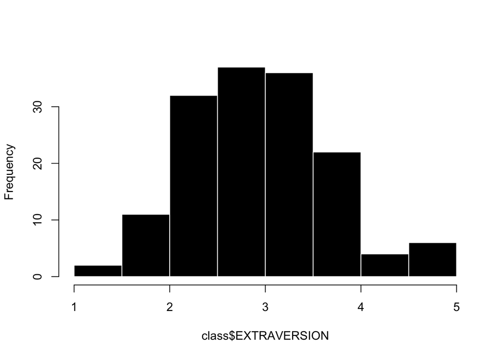

```r
hist(class$EXTRAVERSION, main = "", col = 'black', bor = 'white')
```

Woohoo! This looks good. When I look at this graph I see the following things:

- the range of the scale goes from 1 to 5. This is good, because the response scale ranged from 1 to 5. An incorrect range would suggest that I made a mistake when analyzing the data.
- the graph is mostly normally distributed. This is also good, and expected for a personality variable like Extraversion. If there was some extreme skew, I might again think that I made a mistake when creating the scale, or wonder if there was some non-random variable that was influencing students’ extraversion scores (for example, the entire cohort of students took an improv class during orientation).
- there is some slight positive / right skew - there are a few students who are maxed out on extraversion. What’s up extraverts [waves furiously]. Not sure why that is, but some deviation from normality is always expected! Ooh, one theory is that this survey was given out at the end of a three-hour lecture, so maybe students who were more extraverted were more likely to stick around in a large classroom setting, and thus more likely to be included in the survey. This is an example of sampling bias.

Finally, I’ll examine Cronbach’s $\alpha$. To do this, I’ll use the `alpha()` function that is part of the `psych` package. You’ll need to install the psych package once, using `install.packages('psych')`. Then, you’ll have to load the psych library (see my code below) every time you restart R.

```r
library(psych) # make sure you install.packages("psych") first!
alpha(EXTRA.df)
```

```
##
## Reliability analysis
## Call: alpha(x = EXTRA.df)
##
##   raw_alpha std.alpha G6(smc) average_r S/N   ase mean   sd median_r
##       0.84      0.84    0.84      0.47 5.3 0.021    3 0.75     0.47
##
##  lower alpha upper     95% confidence boundaries
## 0.8 0.84 0.88
##
##  Reliability if an item is dropped:
##          raw_alpha std.alpha G6(smc) average_r S/N alpha se  var.r med.r
## class.e1      0.83      0.83    0.83      0.50 5.0    0.022 0.0121  0.51
## class.e2      0.81      0.81    0.80      0.46 4.3    0.025 0.0161  0.49
## class.e3      0.80      0.81    0.80      0.46 4.2    0.025 0.0157  0.43
## e4r           0.81      0.81    0.81      0.47 4.4    0.025 0.0163  0.49
## e5r           0.78      0.78    0.76      0.42 3.6    0.029 0.0114  0.42
## e6r           0.83      0.84    0.82      0.51 5.1    0.021 0.0064  0.50
##
##  Item statistics
##            n raw.r std.r r.cor r.drop mean   sd
## class.e1 149  0.68  0.68  0.58   0.52  2.7 1.09
## class.e2 150  0.74  0.76  0.70   0.64  3.4 0.85
## class.e3 150  0.76  0.77  0.72   0.64  3.3 1.00
## e4r      149  0.76  0.75  0.69   0.63  3.1 1.03
## e5r      149  0.86  0.85  0.85   0.78  2.9 1.03
## e6r      149  0.67  0.66  0.58   0.50  2.7 1.08
##
## Non missing response frequency for each item
##             1    2    3    4    5 miss
## class.e1 0.13 0.30 0.33 0.18 0.06 0.01
## class.e2 0.03 0.09 0.37 0.45 0.06 0.00
## class.e3 0.05 0.16 0.34 0.36 0.09 0.00
## e4r      0.03 0.31 0.30 0.28 0.09 0.01
## e5r      0.06 0.31 0.34 0.21 0.07 0.01
## e6r      0.13 0.35 0.30 0.15 0.06 0.01
```

There’s a LOT going on in this code, but I’m looking for the number underneath `raw_alpha`, which shows me that this scale is reliable. This is good, and would be something that I would report when describing the measure of Extraversion.

The rest of the code output gives you other statistics on the scale (e.g., the mean or standard deviation), and shows you what the reliability of the scale would be if you removed one of the items from the scale. This can be useful for diagnosing whether there was an issue with your code (e.g., did you forget to reverse-score one item?) or with the scale (e.g., is one of your items actually measuring something other than extraversion?) In this case, the reliability doesn’t change much if we remove any of the items.

Neat! I have a scale! Exciting!!

**Use what you learned in this lecture to complete Lab 4 Problems 1 and 3**

### Click Here to Return to Home (and Complete Part 2)